Skip to contents

# 🎓 教程：西北太平洋（FAO 61区）从零到报告

Source: [`vignettes/articles/zh/tutorial-61.Rmd`](https://github.com/Linbojun99/faofishingreport/blob/main/vignettes/articles/zh/tutorial-61.Rmd)

```r
fao_settings(lang = "zh")   # 本文所有图表使用中文
```

📦 **数据来源**：[FAO全球捕捞产量](https://www.fao.org/fishery/collection/capture/en)（Global Capture Production）**2026.1.0**版（FAO于2026-03-30发布，1950–2024年），下载地址Capture_2026.1.0.zip，许可证[CC BY 4.0](https://creativecommons.org/licenses/by/4.0/)。用`fao_data_info()`查看你使用的版本和引用格式。

本教程以**西北太平洋（FAO 61区）**为例，完整演示一个FAO主要渔区的评估：从一个空白的R会话开始，直到写出一份完整的报告。它按你自己工作时的顺序，用到了本包的几乎每一个函数，并说明**每张图显示什么、怎么看，以及它说明了该渔区的什么情况**。如果你从未用过本包，请从头到尾阅读，边读边运行代码；如果你已经熟悉本包，可以用目录直接跳到需要的步骤。

61区是很好的教学例子：按渔获量计，它是世界上最大的渔区；这里有几个著名的暴涨暴跌物种（拟沙丁鱼和狭鳕）；一个国家（中国）占了大部分渔获量；还有很大一部分渔获量没有鉴定到种。下文中的每个数字都是在生成本页时由数据算出的，因此与图表一致。

| 步骤 | 做什么 | 函数 |
| --- | --- | --- |
| 1 | 准备R、项目文件夹和设置 | `fao_settings()`、`fao_font()` |
| 2 | 获取FAO数据，了解其版本，保存自己的副本 | `check_fao_update()`、`download_fao_data()`、`load_fao_data()`、`fao_data_info()` |
| 3 | 渔区的渔获量：趋势、阶段、占全球的比例 | `fishing_area_data()` |
| 4 | 主要物种 | `fishing_area_species()` |
| 5 | 主要国家 | `fishing_area_country()` |
| 6 | 一个物种，一个国家 | `species_country()`、`country_species()`、`country_analysis()` |
| 7 | 类群结构、资源状态、趋势与突变 | `species_group_composition()`、`stock_status()`、`peak_trend()`、`regime_shift()`、`area_overview()` |
| 8 | 数据质量、多样性与船队 | `data_quality()`、`diversity_concentration()`、`country_group_summary()`、`coastal_distant()` |
| 9 | 文献中的方法 | `catch_shocks()`、`collapse_analysis()`、`catch_synchrony()`、`pelagic_demersal()`、`distant_water_profile()` |
| 10 | 物种特征与温度 | `fishbase_match()`、`fao_area_sst()`、`mean_temperature_catch()` |
| 11 | 主要物种的资源评估 | `cmsy_setup()`、`cmsy_area()` |
| 12 | Word、LaTeX和PDF格式的报告 | `fao_report()` |
| 13 | 所有文件保存在哪里，以及如何重新读取 |  |

**图表的解读方式。**每张图下方，“🔎 怎么看这张图”说明坐标轴、颜色和线条的含义，“61区的结果”给出该渔区的结果。图表描述的是**报告的渔获量**：它们说明的是上岸并上报给FAO的渔获量，而不是海里有多少鱼。得出每一个结论时都要记住这一点。

## 1. 🧰 准备工作

安装一次本包，同时安装它用到的所有包（详见🚀 快速入门），然后在每次会话开始时加载它：

```r
install.packages("remotes")
remotes::install_github("Linbojun99/faofishingreport", dependencies = TRUE)
```

```r
library(faofishingreport)
```

**在项目文件夹中工作。**每个函数都把图表和表格保存在*工作目录*（`getwd()`返回的文件夹）中。每项评估建一个文件夹，例如建一个RStudio项目，或者自己设置：

```r
dir.create("~/fao61", showWarnings = FALSE)
setwd("~/fao61")
getwd()
```

**为本次会话一次性选好设置**：用`fao_settings()`设置图表的语言、风格和输出格式。不带参数调用它，可以查看当前的设置。

```r
fao_settings(lang = "zh", theme = "classic", dpi = 100, pptx = FALSE)
```

| 设置 | 本文取值 | 作用 |
| --- | --- | --- |
| `lang` | `"zh"` | 图表文字和名称使用中文；`"en"`为英文，`"both"`为中英双语 |
| `theme` | `"classic"` | 图表风格（见🎨 自定义图表与地图） |
| `dpi` | `100` | PNG文件的分辨率（印刷用300） |
| `pptx` | `FALSE` | `TRUE`时把每张图同时保存为可编辑的PowerPoint文件 |

图表字体会按你的操作系统选择（`fao_font()`显示所用的字体）：Windows上为SimSun，macOS上为Songti SC，Linux上为Noto Serif CJK SC，以保证中文名称能正常显示。

## 2. 💾 获取数据

### 2.1 检查FAO的最新版本

FAO每年发布一次全球捕捞产量（Global Capture Production）统计。本包自带一个较新的版本；`check_fao_update()`把它与网上的最新版本比较，`download_fao_data()`下载并转换一个版本（约5 MB，通常不到一分钟）：

```r
check_fao_update()     # 比较网上的最新版本与你电脑上的数据
download_fao_data()    # 下载最新版本（只有FAO发布了新版本时才需要）
```

### 2.2 加载数据，并确认所用的版本

`load_fao_data()`返回你电脑上可用的最新版本（下载过的版本，否则为本包自带的版本），每个国家、物种条目、渔区和年份一行：

```r
fao <- load_fao_data()
dim(fao)
```

```
#> [1] 1024698       8
```

```r
show_table(fao[fao$FAO.major.fishing.area..Name. == "Pacific, Northwest" & fao$Year == 2024, ], n = 5)
```

|  | Country..Name. | ASFIS.species..Name. | FAO.major.fishing.area..Name. | Unit..Name. | Unit | Year | Production | Production.Type |
| --- | --- | --- | --- | --- | --- | --- | --- | --- |
| 114028 | China | Elongate ilisha | Pacific, Northwest | Tonnes - live weight | TLW, Number | 2024 | 60,739 | actual |
| 114287 | China | Flathead grey mullet | Pacific, Northwest | Tonnes - live weight | TLW, Number | 2024 | 69,028 | actual |
| 114309 | China | So-iny (redlip) mullet | Pacific, Northwest | Tonnes - live weight | TLW, Number | 2024 | 98,932 | actual |
| 114344 | China | Groupers nei | Pacific, Northwest | Tonnes - live weight | TLW, Number | 2024 | 111,646 | actual |
| 114449 | China | Pacific sandlance | Pacific, Northwest | Tonnes - live weight | TLW, Number | 2024 | 81,171 | actual |

| 列 | 含义 |
| --- | --- |
| `Country..Name.` | 上报国家（FAO英文名） |
| `ASFIS.species..Name.` | FAO物种条目（一个种、属、科，或“Marine fishes nei”这样的类群；*nei* = not elsewhere included，即“未另列明”） |
| `FAO.major.fishing.area..Name.` | FAO主要渔区 |
| `Year`、`Production` | 年份和渔获量（吨，活重） |
| `Production.Type` | 数值是怎样得来的：国家上报、FAO估算…… |

**务必记录所用的版本**：FAO每发布一个新版本都会修订以前的年份，所以报告必须说明它依据的是哪个版本。`fao_data_info()`给出版本号、相关日期、下载链接和引用格式：

```r
info <- fao_data_info()
info
```

```
#> FAO Global Capture Production
#>   Release:   2026.1.0 (published by FAO on 2026-03-30)
#>   Years:     1950-2024
#>   File:      https://www.fao.org/fishery/static/Data/Capture_2026.1.0.zip
#>   Obtained:  bundled with faofishingreport, downloaded from FAO on 2026-10-10
#>   Licence:   CC BY 4.0 (https://www.fao.org/contact-us/terms/db-terms-of-use/en)
#>   Citation:  FAO. 2026. Global Capture Production 1950-2024, release 2026.1.0. In: Fisheries and Aquaculture [online]. Rome. [Cited 10 October 2026]. https://www.fao.org/fishery/collection/capture/en. Licence: CC BY 4.0.
```

### 2.3 数据保存在哪里

下载的版本保存在本包的数据文件夹`fao_data_dir()`中，以后每次会话都会再用。要在多台电脑之间或团队内共用一个文件夹，在`~/.Renviron`中设置环境变量`FAOFISHINGREPORT_DATA_DIR`（见💾 FAO数据：下载与自定义）。某个渔区的数据可以像任何R对象一样另存一份副本：

```r
fao_data_dir()
```

```
#> [1] "/home/runner/.local/share/R/faofishingreport"
```

```r
area61_raw <- fao[fao$FAO.major.fishing.area..Name. == "Pacific, Northwest", ]
saveRDS(area61_raw, "area61_data.rds")                 # 在R中读取：readRDS("area61_data.rds")
write.csv(area61_raw, "area61_data.csv", row.names = FALSE, fileEncoding = "UTF-8")   # 用Excel打开
```

## 3. 🌊 渔区的渔获量

`fishing_area_data()`的输入是一个FAO主要渔区的名称，它提取该渔区的数据，绘制总渔获量及其阶段，以及该渔区占全球海洋渔获量的比例：

```r
NWP <- fishing_area_data("Pacific, Northwest")
area61 <- NWP$area_data
```

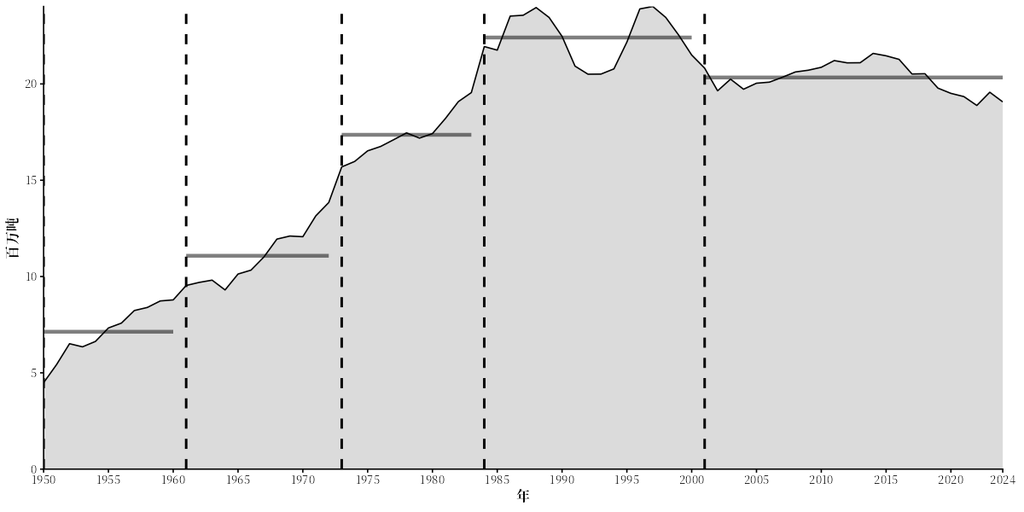

`figures/png/fishing_trend.png`

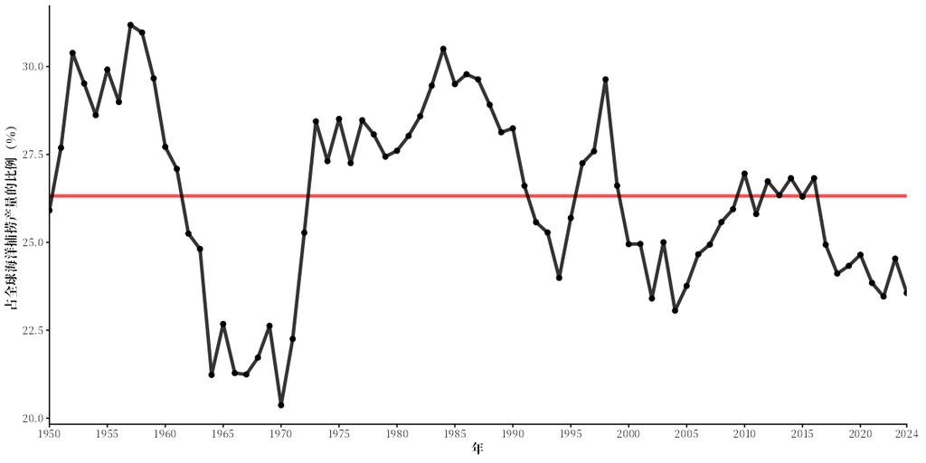

`figures/png/fishing_percentage.png`

**`fishing_trend.png`：总渔获量及其阶段**

🔎 *怎么看这张图*：灰色面积是该渔区每年的渔获量（百万吨）。竖直虚线是**突变点**，即平均渔获量发生变化的年份，用Bai-Perron检验（`strucchange::breakpoints()`）找出；每条虚线处开始一个新的阶段。灰色水平线段是各阶段的平均渔获量。

*61区的结果*：渔获量从1950年的448.6万t增长到1997年的峰值2402.1万t，2024年为1906.8万t。检验共找出5个阶段：1950–1960年（平均713.3万t）；1961–1972年（平均1107.7万t）；1973–1983年（平均1735.9万t）；1984–2000年（平均2241.0万t）；2001–2024年（平均2033.5万t）。1950–1980年代的增长、1980年代末和1990年代的高位平台，以及2001年以来较低而平稳的渔获量，是报告中需要解释的三件事。

**`fishing_percentage.png`：占全球海洋渔获量的比例**

🔎 *怎么看这张图*：每个点是当年该渔区渔获量占所有FAO海洋渔区渔获量的百分比；红线是这些比例的平均值。内陆水域不计算在内。

*61区的结果*：该渔区占全球海洋渔获量的20.4%至31.2%，平均为26.3%，2024年为23.6%。比例高于其平均值，说明该渔区的增长快于（或下降慢于）世界其他海域。

`NWP`是一个列表：`NWP$area_data`（该渔区的数据，后面各步都要用到）、`NWP$coefs_data`（各阶段：起止年份和平均渔获量）和`NWP$act_world_map`（地图数据）。用`saveRDS(NWP, "NWP.rds")`保存，以后可以接着分析而不必重新计算。

## 4. 🐟 主要物种

`fishing_area_species()`按渔获量给物种条目排序（`rank_range = c(1, 10)`：最大的十个），绘制它们的渔获量随时间的变化，并找出每个物种的阶段：

```r
sp <- fishing_area_species(area61, rank_range = c(1, 10))
```

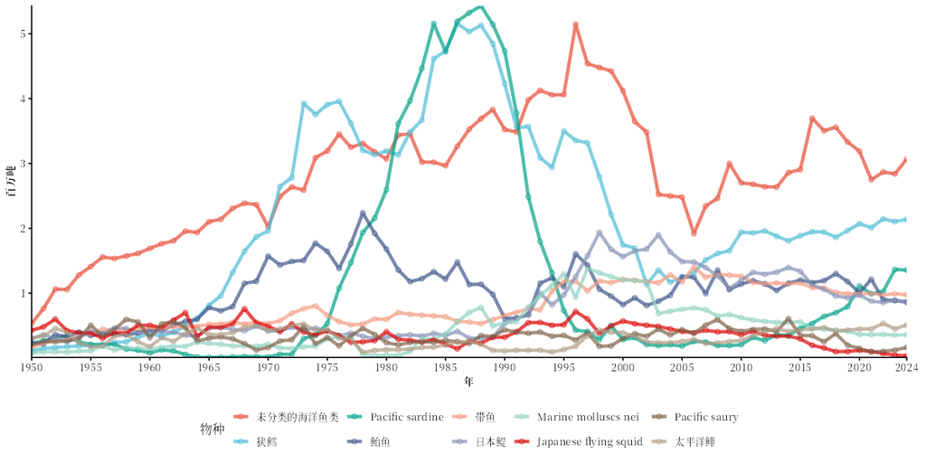

`figures/png/area/area_species.png`

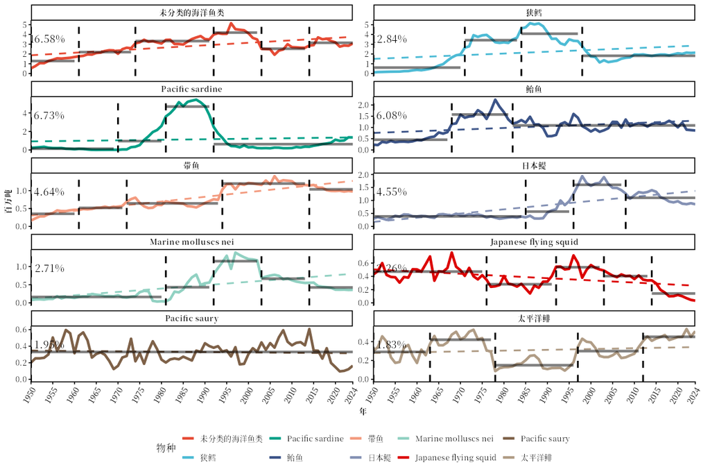

`figures/png/area/area_species_wrap.png`

**`area_species.png`：主要物种放在一起**，以及**`area_species_wrap.png`：每个物种一个分面**

🔎 *怎么看这些图*：第一张图把十个物种条目放在同一个纵轴上，以便比较它们的大小。第二张图给每个物种一个单独的分面和纵轴，这样小物种也看得清：折线是每年的渔获量，竖直虚线和灰色线段是该物种的阶段，倾斜的虚线是线性趋势，百分比是该物种在该渔区历年渔获量中所占的比例。

*61区的结果*：最近五年最大的条目是未分类的海洋鱼类（每年294.3万t）、狭鳕（每年209.4万t）、Pacific sardine（每年116.9万t）、带鱼（每年98.5万t）、鲐鱼（每年97.5万t）。有三个特点很突出：

- **“Marine fishes nei”（未分类的海洋鱼类）是最大的条目。**它不是一个物种，而是各国上报时没有说明种类的鱼。“nei”的占比大，限制了物种图所能说明的内容（见数据质量）。
- **暴涨暴跌。**拟沙丁鱼（Pacific sardine）的渔获量从几乎为零增长到1988年的峰值542.9万t，又在二十年内回落到很低的水平，这是沙丁鱼类种群随海洋环境大幅波动的著名例子；近年它的渔获量又有所回升。
- **狭鳕**的渔获量在1980年代末达到峰值，1990年代随着前苏联和日本渔获量的下降而减少。

改变`rank_range`就会改变显示的物种，例如`rank_range = c(11, 20)`显示其后的十个。只有在`timeseries_analysis = FALSE`时，分面中的折线才会被平滑，同时也不再显示阶段。

FAO物种名录（ASFIS）中有些物种条目没有中文名（如Pacific sardine，即拟沙丁鱼），图表和表格中这些物种显示英文名。

## 5. 🌏 主要国家

```r
co <- fishing_area_country(area61, rank_range = c(1, 8))
```

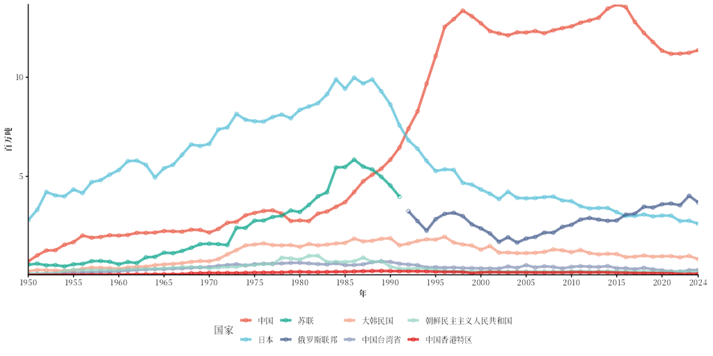

`figures/png/area/area_country.png`

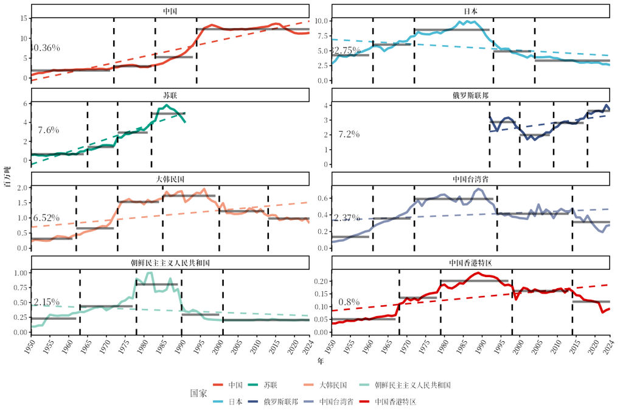

`figures/png/area/area_country_wrap.png`

*61区的结果*：最近五年，中国（58.4%）、俄罗斯联邦（19.2%）、日本（14.7%）、大韩民国（4.9%）占了大部分渔获量。**中国**的渔获量从1950年的71.6万t增长到2015年的峰值1366.8万t；**日本**直到1991年都是该渔区渔获量最大的国家（峰值为1986年的998.2万t；从1992年起中国每年的渔获量都超过日本），2024年的渔获量为261.4万t。**前苏联**的分面到1991年结束，**俄罗斯联邦**的分面从1992年开始：FAO把它们作为两个国家分别记录，所以应把两者的阶段放在一起看。

## 6. 🔍 一个物种，一个国家

### 6.1 谁在捕捞某个物种：`species_country()`

```r
pollock <- species_country(area61, "Alaska pollock(=Walleye poll.)", rank_range = c(1, 5))
```

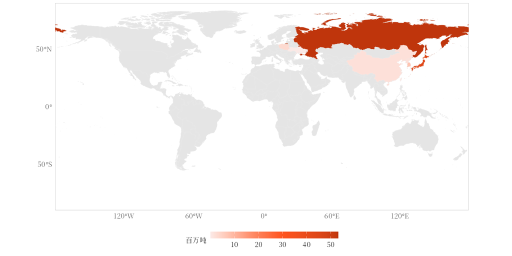

`figures/png/Alaska_pollock__Walleye_poll___country_map.png`

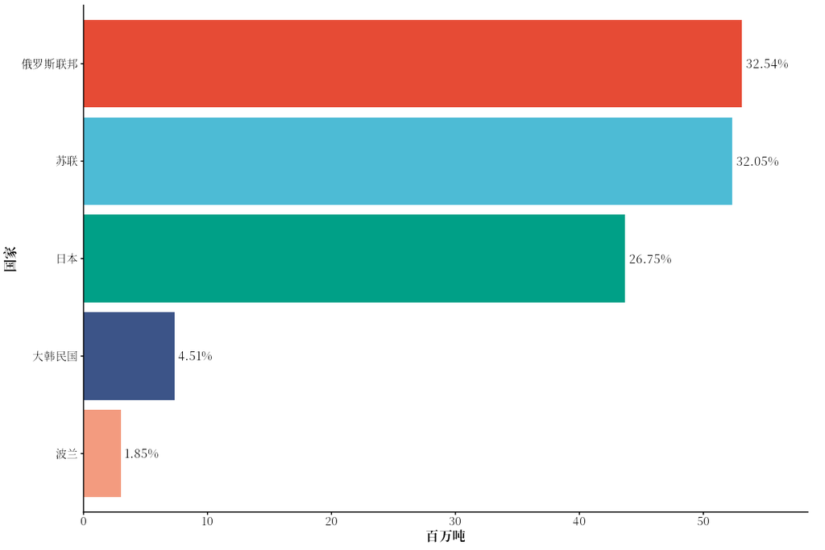

`figures/png/species/Alaska_pollock__Walleye_poll___country_ranked_total.png`

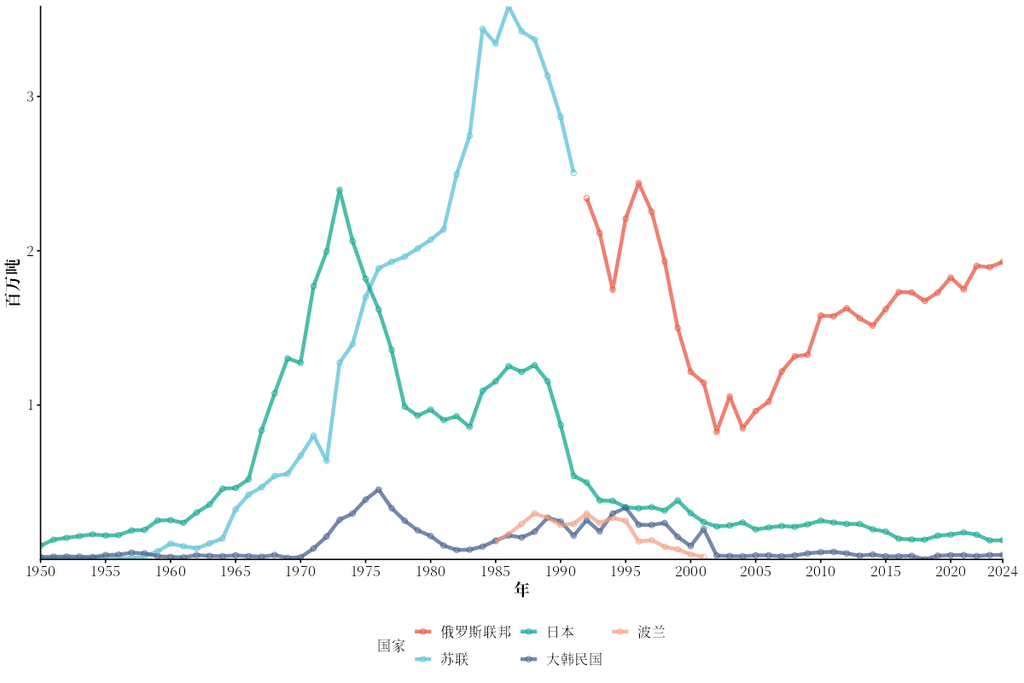

`figures/png/species/Alaska_pollock__Walleye_poll___country_ranked.png`

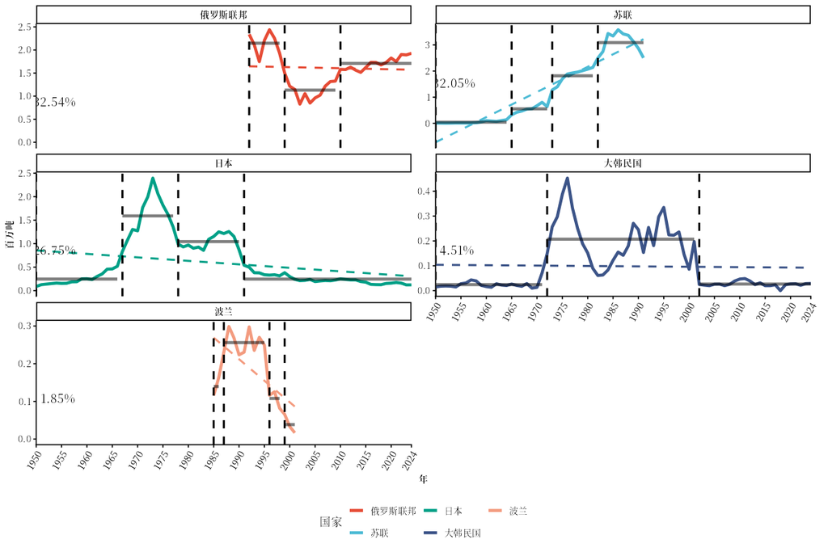

`figures/png/species/Alaska_pollock__Walleye_poll___country_ranked_wrap.png`

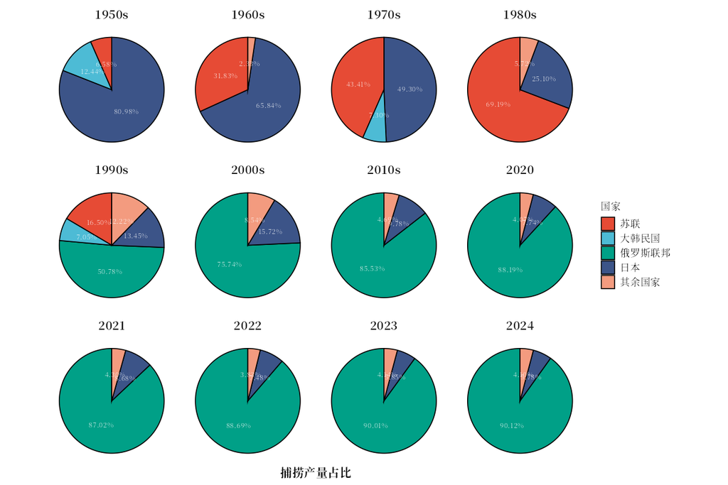

`figures/png/species/Alaska_pollock__Walleye_poll___country_pie_selected.png`

🔎 *怎么看这些图*：这些图把一个物种条目的渔获量按国家分解：排名图和小多图（每个国家一个分面，带阶段）、按时期显示各国占比的饼图，以及一张地图。物种名称必须按FAO数据中的写法给出（`unique(area61$ASFIS.species..Name.)`列出全部名称；`fao_translate()`给出中文名）。

*61区的结果*：西北太平洋的狭鳕主要由前苏联（后为俄罗斯联邦）、日本和大韩民国捕捞；日本的渔获量在1970年代初达到峰值，苏联在1980年代末达到峰值，波兰在1980年代末和1990年代也捕捞狭鳕。

### 6.2 一个国家捕什么：`country_species()`和`country_analysis()`

`country_species()`把一个国家在该渔区的渔获量按物种分解；`country_analysis()`考察同一个国家在**所有**FAO渔区的渔获量，看它在哪里捕捞：

```r
japan_61 <- country_species(area61, "Japan", rank_range = c(1, 10))
japan_all <- country_analysis("Japan", rank_range = c(1, 10))
```

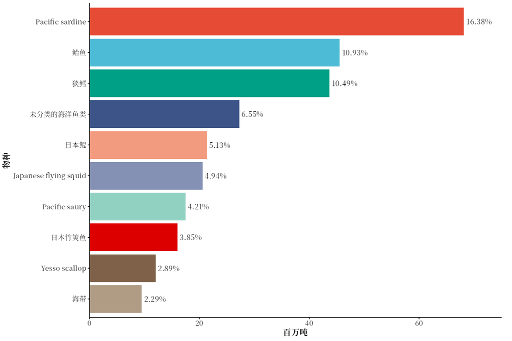

`figures/png/country/Japan_species_ranked_total.png`

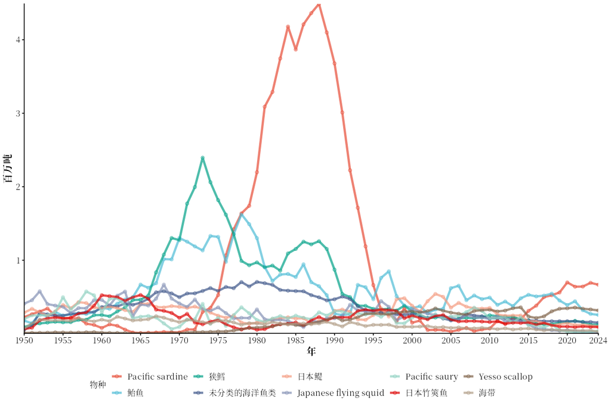

`figures/png/country/Japan_species_ranked.png`

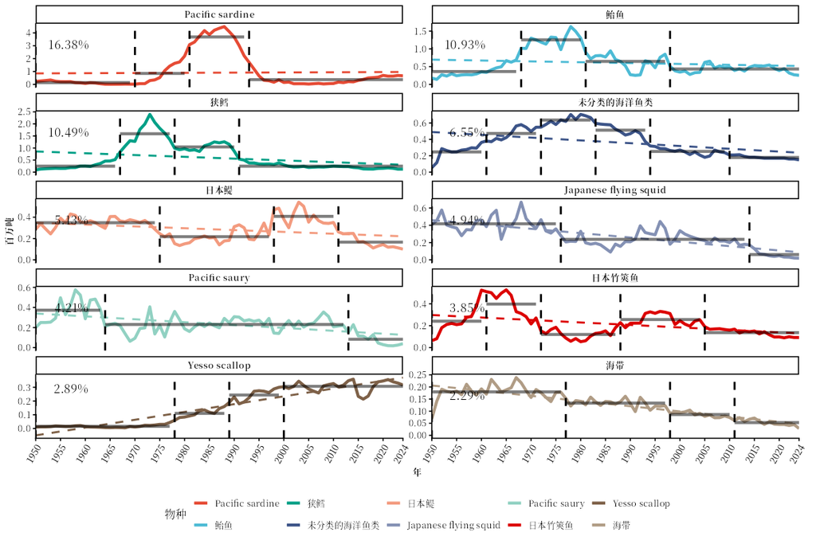

`figures/png/country/Japan_species_ranked_wrap.png`

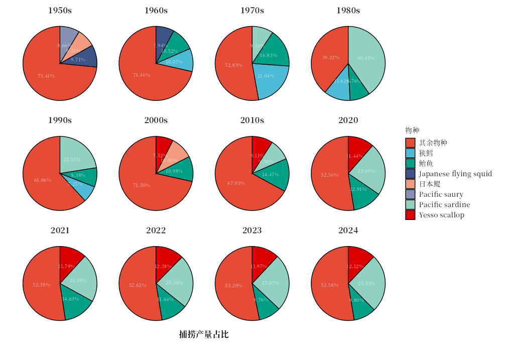

`figures/png/country/Japan_species_pie_selected.png`

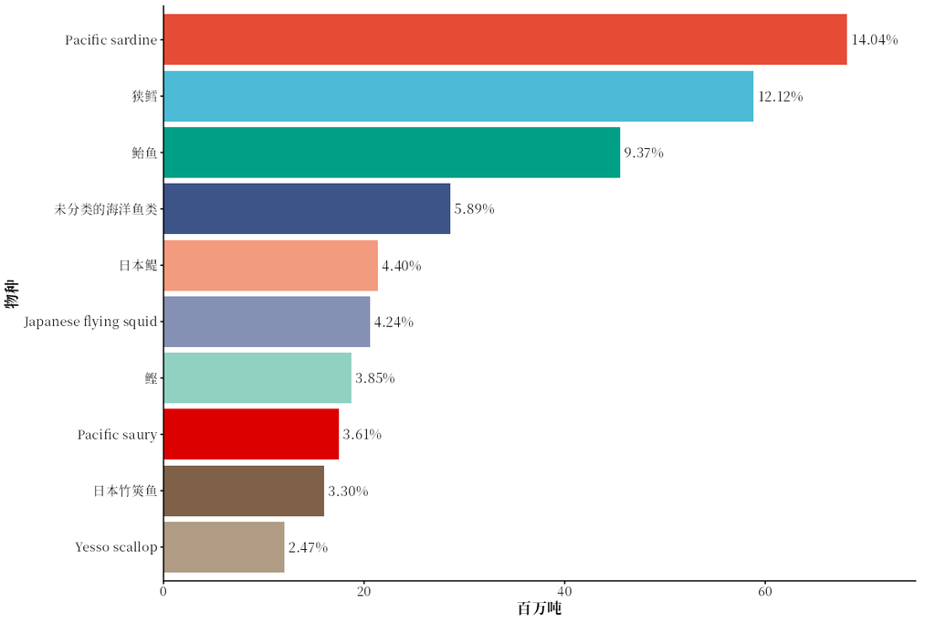

`figures/png/country/Japananalysis_species_ranked_total.png`

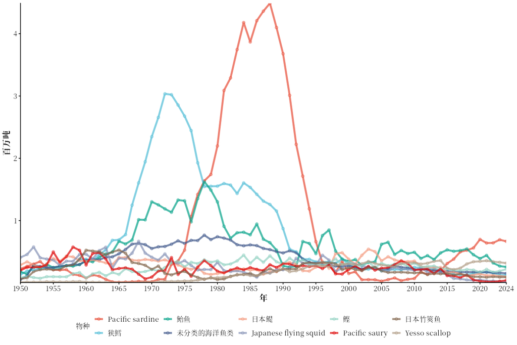

`figures/png/country/Japananalysis_species_ranked.png`

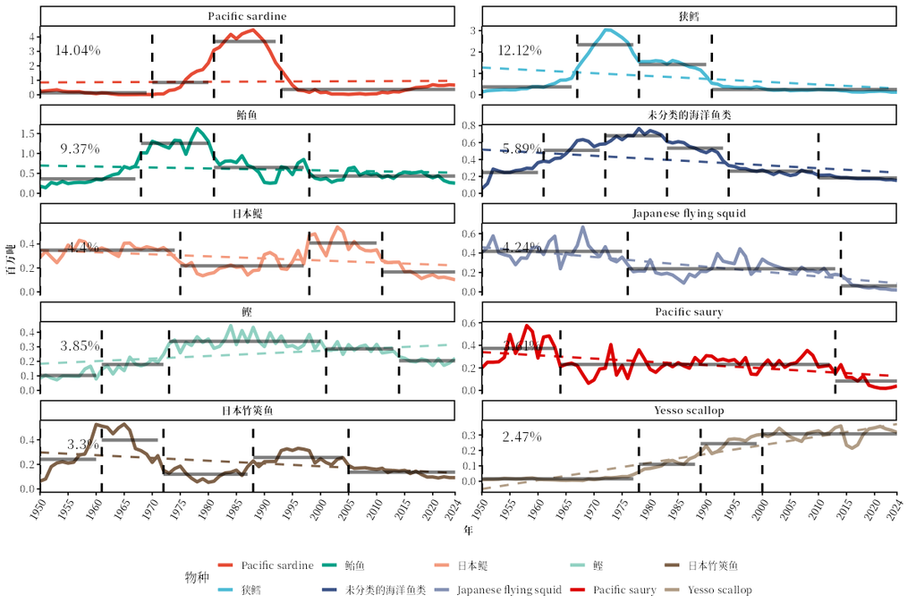

`figures/png/country/Japananalysis_species_ranked_wrap.png`

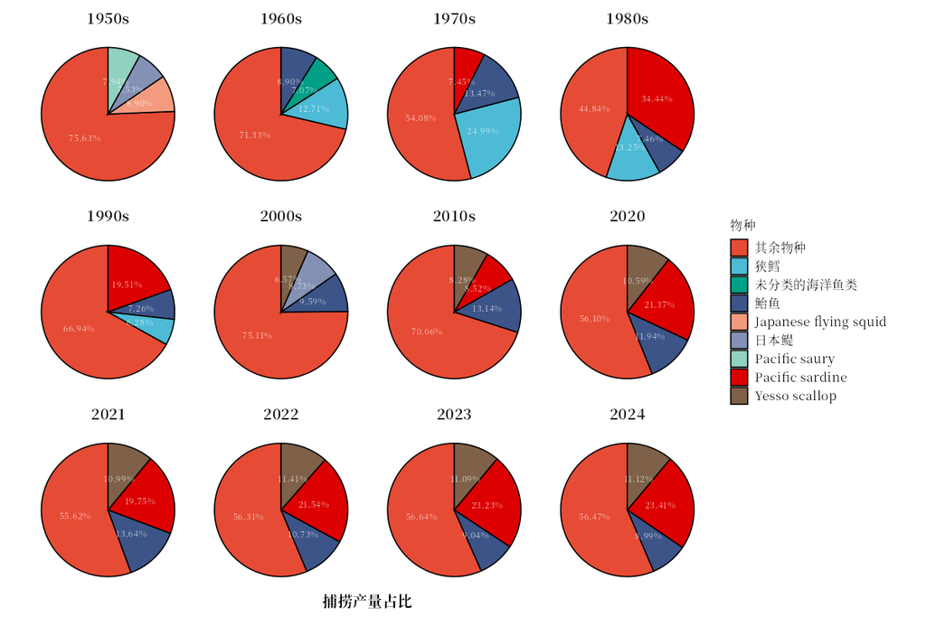

`figures/png/country/Japananalysis_species_pie_selected.png`

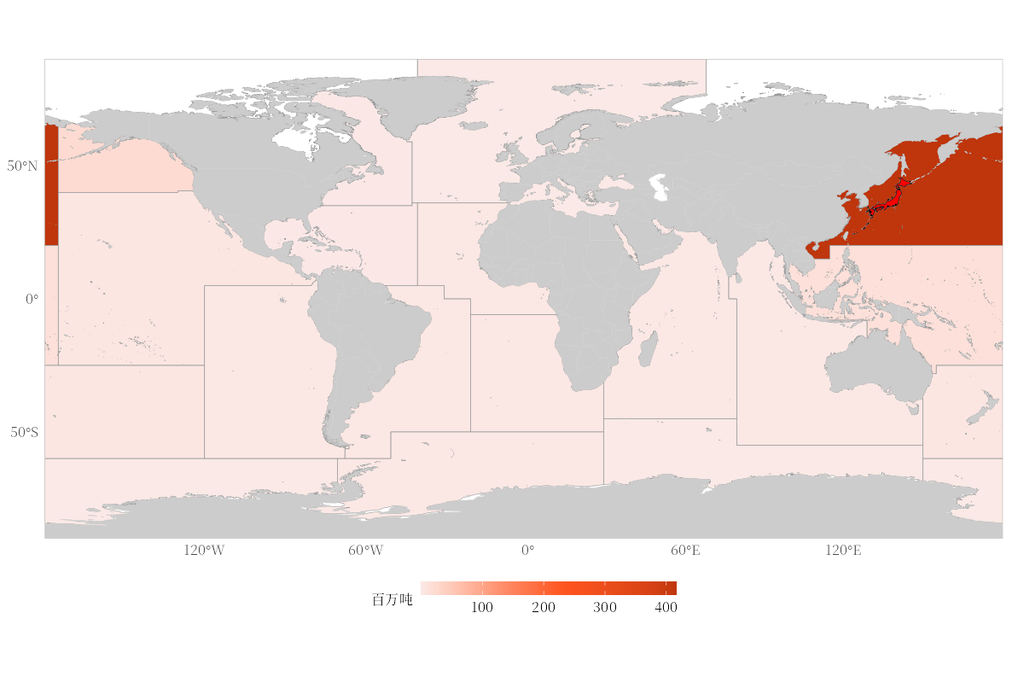

`figures/png/country/Japanfishing_area_map.png`

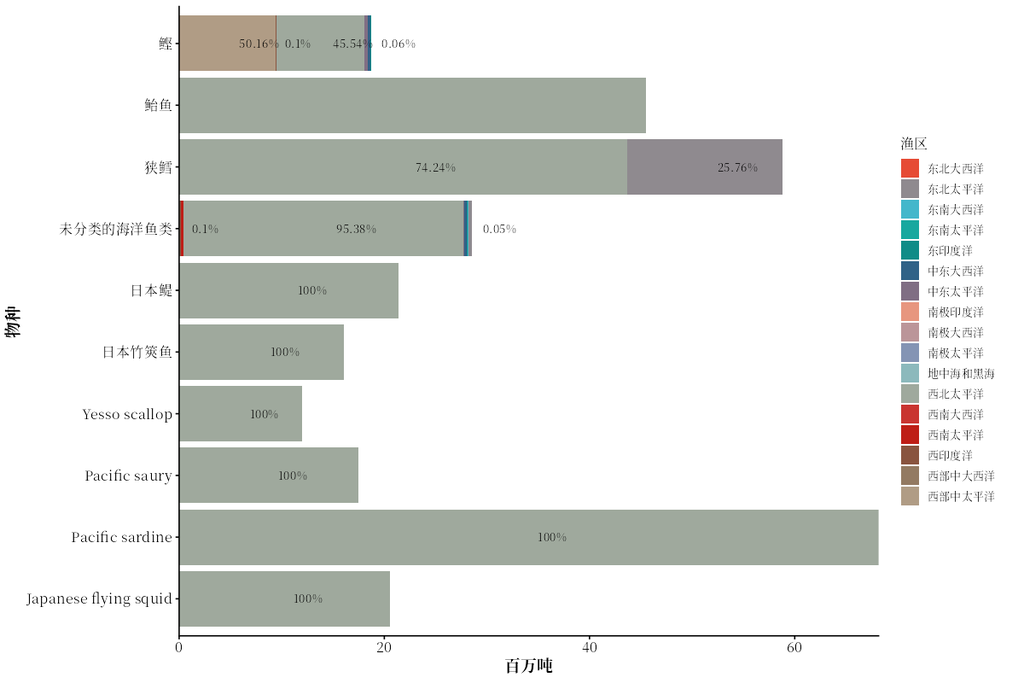

`figures/png/country/Japananalysis_species_by_area.png`

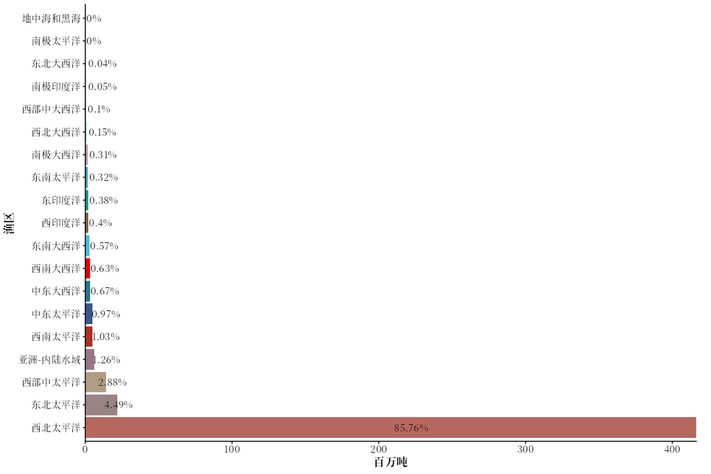

`figures/png/country/Japananalysis_area_total_production.png`

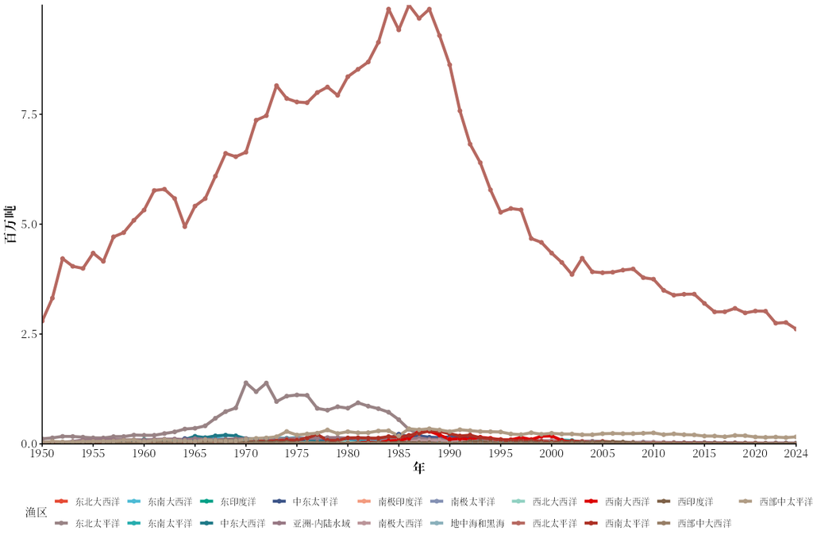

`figures/png/country/Japanyearly_area_production.png`

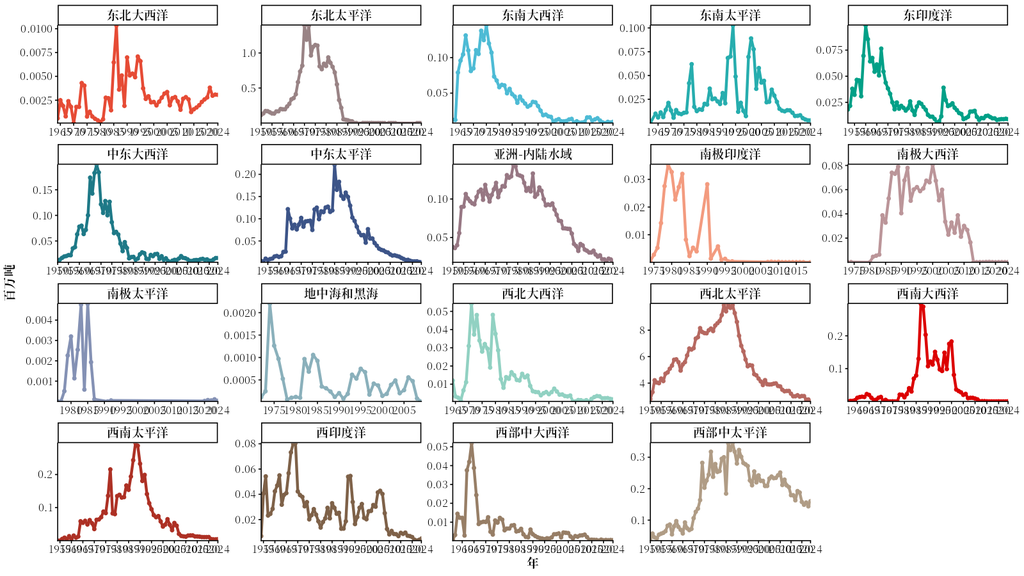

`figures/png/country/Japanyearly_area_production_wrap.png`

🔎 *怎么看这些图*：`Japan_species_*`图：日本在61区捕捞的物种。`Japananalysis_*`图：日本在所有渔区捕捞的物种、它在各渔区的渔获量（`Japanyearly_area_production.png`，每个渔区一条线），以及它作业渔区的地图。

*结果*：日本在61区的渔获量，1980年代以拟沙丁鱼为主；此后的主要物种是鲐鱼、再次回升的拟沙丁鱼、虾夷扇贝和日本鳀（狭鳕主要在1990年代以前较重要）；61区一直是日本最大的渔区，远超其他渔区，而日本在这里的渔获量自1980年代末以来持续下降。

## 7. 📈 类群结构、资源状态、趋势与突变

### 7.1 物种类群：`species_group_composition()`

```r
groups <- species_group_composition(area61)
```

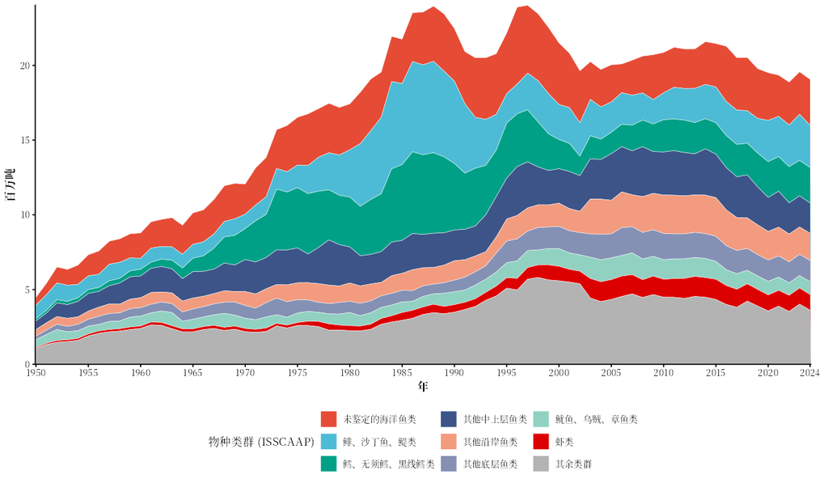

`figures/png/summary/Pacific__Northwest_group_isscaap.png`

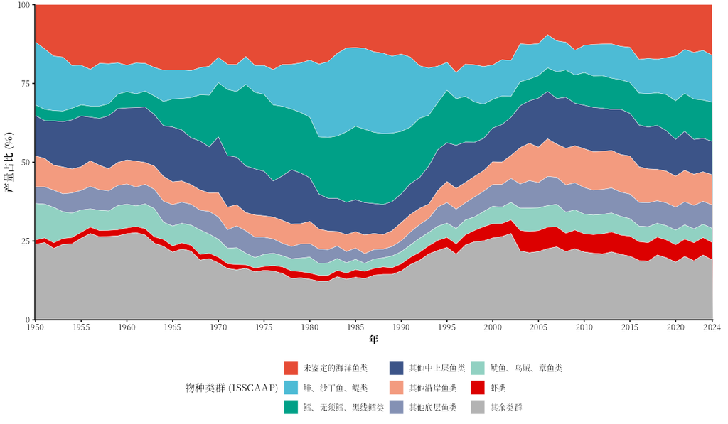

`figures/png/summary/Pacific__Northwest_group_isscaap_share.png`

🔎 *怎么看这张图*：物种条目按FAO的ISSCAAP类群归类（如“鲱、沙丁鱼、鳀类”“鳕、无须鳕、黑线鳕类”）。堆积面积图显示每个类群的渔获量，`_share`图显示其占渔获量的百分比；最大的几个类群单独标出名称，其余合并为“其余类群”。

*61区的结果*：1980年代，鳕、无须鳕、黑线鳕类（主要是狭鳕）和鲱、沙丁鱼、鳀类（主要是拟沙丁鱼和日本鳀）所占的份额最大；2000年代以来，渔获量分布在更多的类群中，其他沿岸鱼类、其他中上层鱼类、鱿鱼和虾类的份额增大。

### 7.2 资源状态图：`stock_status()`

```r
status <- stock_status(area61)
```

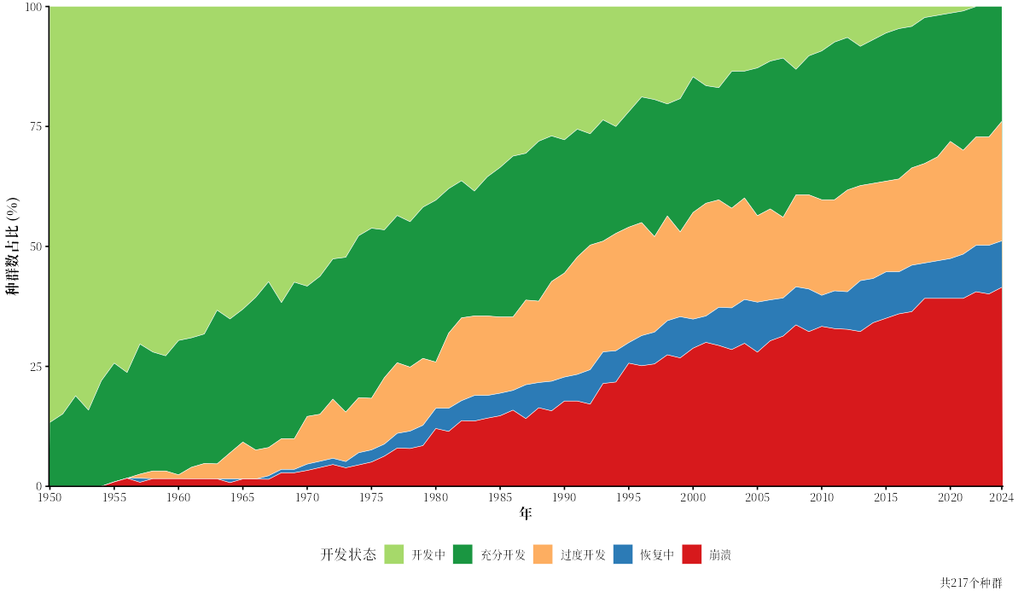

`figures/png/summary/Pacific__Northwest_stock_status_stocks.png`

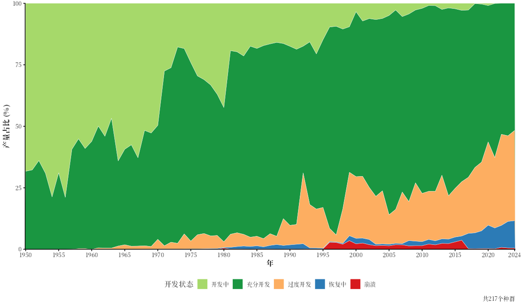

`figures/png/summary/Pacific__Northwest_stock_status_catch.png`

🔎 *怎么看这些图*：每个“种群”是该渔区一个物种条目的渔获量序列。每一年，按种群渔获量相对于其自身峰值的比例划分状态（Kleisner等，2013）：**开发中**（峰值之前，低于峰值的一半）、**充分开发**（高于峰值的一半）、**过度开发**（峰值之后，为峰值的10%–50%）、**崩溃**（峰值之后，低于10%）和**恢复中**（崩溃之后回升到10%–50%）。`_stocks`图统计种群数，`_catch`图按渔获量加权。

*61区的结果*：在217个种群中，按种群数计，2024年有41.5%处于崩溃状态，24.9%处于过度开发状态。按渔获量加权，情况就不同了：崩溃种群只占渔获量的0.5%，因为它们都很小；过度开发种群占36.7%，充分开发种群占51.7%。许多小种群已经远低于其峰值，而现在很大一部分渔获量来自低于其峰值一半的种群。

**不能得出的结论。**资源状态图只使用渔获量。渔获量下降可能是因为鱼变少了，也可能是因为捕捞减少、管理措施、市场或上报方式的变化（例如某个物种改为以“nei”上报）。用它来提出问题，而不要把它当作资源评估；`smooth = TRUE`按3年滑动平均划分状态，可以减小个别异常年份的影响。

### 7.3 各物种的峰值与趋势：`peak_trend()`

```r
pt <- peak_trend(area61)
show_table(pt[, c("name", "peak_year", "pct_of_peak", "growth_pct_per_year", "trend")], n = 10)
```

[output not shown]

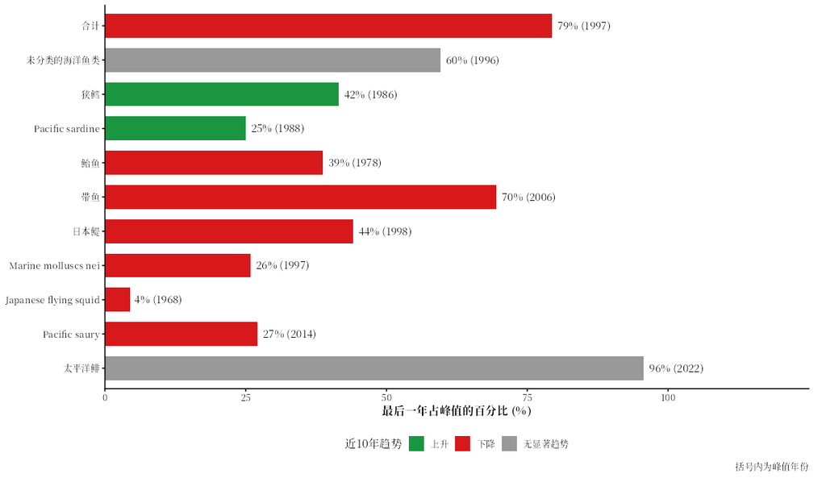

`figures/png/summary/Pacific__Northwest_peak_trend_species.png`

🔎 *怎么看这张图*：对每个主要物种给出：峰值渔获量出现的年份，最后一年的渔获量相当于峰值的百分比，最近十年的年均增长率，以及这一趋势的Mann-Kendall检验（*P* < 0.05时为`"up"`（上升）或`"down"`（下降），否则为`"none"`）。

### 7.4 同步突变：`regime_shift()`

```r
shifts <- regime_shift(area61)
```

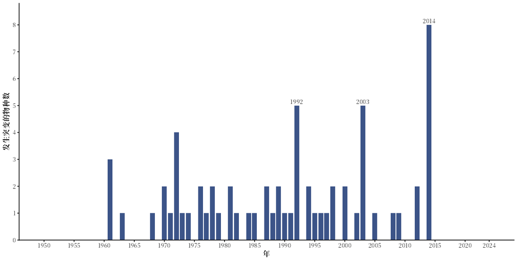

`figures/png/summary/Pacific__Northwest_regime_shift.png`

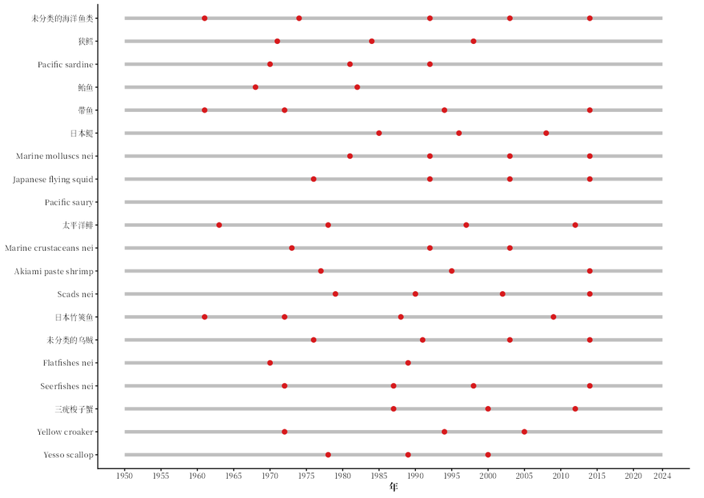

`figures/png/summary/Pacific__Northwest_regime_shift_species.png`

🔎 *怎么看这张图*：每个主要物种的突变点按第4步的方法找出；柱状图统计每一年有多少个物种的平均渔获量在该年发生了变化。许多物种在同一年一起变化，说明存在共同的原因：海洋环境（生态系统转变，regime shift）、管理措施的改变，或上报方式的改变。

*61区的结果*：同时出现突变点最多的年份是2014年（8个物种）、1992年（5个物种）、2003年（5个物种）。